# **Importing necessory libraries**

1. Pandas
2. NumPy
3. Seaborn
4. Matplotlib
5. Wordcloud

```python
import pandas as pd
import numpy as np
import seaborn as sns
from matplotlib import pyplot as plt
from wordcloud import WordCloud
import warnings
warnings.filterwarnings('ignore')
```

# *Data Extraction*

```python
data = pd.read_csv('Swiggy Bangalore Outlet Details.csv')
```

```python
data.head()
```

|  | Shop_Name | Cuisine | Location | Rating | Cost_for_Two |
| --- | --- | --- | --- | --- | --- |
| 0 | Kanti Sweets | Sweets | Koramangala, Koramangala | 4.3 | ₹ 150 |
| 1 | Mumbai Tiffin | North Indian, Home Food, Thalis, Combo | Sector 5, HSR | 4.4 | ₹ 400 |
| 2 | Sri Krishna sagar | South Indian, North Indian, Fast Food, Beverag... | 6th Block, Koramangala | 4.1 | ₹ 126 |
| 3 | Al Daaz | American, Arabian, Chinese, Desserts, Fast Foo... | HSR, HSR | 4.4 | ₹ 400 |
| 4 | Beijing Bites | Chinese, Thai | 5th Block, Koramangala | 4.1 | ₹ 450 |

```python
data.tail()
```

|  | Shop_Name | Cuisine | Location | Rating | Cost_for_Two |
| --- | --- | --- | --- | --- | --- |
| 113 | Wok Paper Scissors | Pan-Asian, Chinese, Asian | JNC Road, Koramangala | 3.9 | ₹ 219 |
| 114 | Savoury Restaurant | Arabian, Middle Eastern, North Indian, Grill, ... | Madiwala, BTM | 4.1 | ₹ 600 |
| 115 | Royal Treat | North Indian, Chinese, Seafood, Biryani | 5th block Koramangala, Koramangala | 4.2 | ₹ 193 |
| 116 | Thali 99 | North Indian | Koramangala, Koramangala | 4.3 | ₹ 200 |
| 117 | Mani's Dum Biryani | Andhra, Biryani | 1st Block, Koramangala | 4.2 | ₹ 400 |

```python
data.shape
```

```
(118, 5)
```

```python
data.columns
```

```
Index(['Shop_Name', 'Cuisine', 'Location', 'Rating', 'Cost_for_Two'], dtype='object')
```

```python
data.info()
```

```
<class 'pandas.core.frame.DataFrame'>
RangeIndex: 118 entries, 0 to 117
Data columns (total 5 columns):
 #   Column        Non-Null Count  Dtype
---  ------        --------------  -----
 0   Shop_Name     118 non-null    object
 1   Cuisine       118 non-null    object
 2   Location      118 non-null    object
 3   Rating        118 non-null    object
 4   Cost_for_Two  118 non-null    object
dtypes: object(5)
memory usage: 4.7+ KB
```

# *Data Cleaning*

```python
print(f"Checking Total null values in data :")
data.isna().sum().sum()
```

```
Checking Total null values in data :
```

```
0
```

```python
print(f"Checking Total null Values in all columns of data :")
data.isna().sum()
```

```
Checking Total null Values in all columns of data :
```

```
Shop_Name       0
Cuisine         0
Location        0
Rating          0
Cost_for_Two    0
dtype: int64
```

```python
data.duplicated().sum()
```

```
0
```

# *Data Transformation*

1. Replace "--" value with "0" in 'Rating' attribute
2. Changing 'Rating' attribute data type to float
3. Removing "₹" symbol from attribute named 'Cost_for_Two'
4. Changing 'Cost_for_Two' data type to int
5. Creating 'Average_Cost' attribute from 'Cost_for_Two'
6. Creating 'Cost_Category' attribute from 'Average_Cost'
   - cost less than 150 => "low"
   - cost between 150 and 250 => "medium"
   - cost greater than 250 => "high"
7. Dividing 'Location' attribute into two attribute 'Street' and 'Area' attributes.
8. Counting 'Total_Cuisine' attribute from 'Cuisine' attribute
9. Drop unwanted attributes from the dataset
10. Create CSV file named 'Swiggy Bangalore Outlet Details Transformed.csv' and store transformed data

```python
# Replace "--" value with "0" in 'Rating' attribute
print(data['Rating'].unique())
data['Rating'].replace('--','0', inplace=True)
```

```
['4.3' '4.4' '4.1' '4.2' '3.9' '3.8' '4' '3.7' '3.6' '4.8' '4.5' '4.6'
 '--']
```

```python
# Changing 'Rating' attribute data type to float
data['Rating'] = data['Rating'].astype(str).astype(float)
```

```python
# Removing "₹" symbol from attribute named 'Cost_for_Two'
print(data['Cost_for_Two'])
def remove_prefix(s):
    # s = s.replace('₹ ',' ')
    return s.replace('₹ ',' ').strip()
data['Cost_for_Two'] = data['Cost_for_Two'].apply(remove_prefix)
```

```
0      ₹ 150
1      ₹ 400
2      ₹ 126
3      ₹ 400
4      ₹ 450
       ...
113    ₹ 219
114    ₹ 600
115    ₹ 193
116    ₹ 200
117    ₹ 400
Name: Cost_for_Two, Length: 118, dtype: object
```

```python
# Changing 'Cost_for_Two' data type to int
data['Cost_for_Two'] = data['Cost_for_Two'].astype(str).astype(int)
```

```python
# Creating 'Average_Cost' attribute from 'Cost_for_Two'
data['Average_Cost'] = data['Cost_for_Two'] / 2
```

```python
# Creating 'Cost_Category' attribute from 'Average_Cost'
#     1. cost less than 150         => "low"
#     2. cost between 150 and 250   => "medium"
#     3. cost greater than 250      => "high"
def get_category(cost):
    if cost < 150:
        return "low"
    elif cost <= 250:
        return "medium"
    else:
        return "high"
data['Cost_Category'] = data['Average_Cost'].apply(get_category)
```

```python
# Dividing 'Location' attribute into two attribute 'Street' and 'Area' attributes.
def get_area_from_location(address):
    return address.split(',')[-1].strip()

def get_street_from_location(address):
    return address.split(',')[0].strip()

data['Street'] = data['Location'].apply(get_street_from_location)
data['Area'] = data['Location'].apply(get_area_from_location)
```

```python
# Counting 'Total_Cuisine' attribute from 'Cuisine' attribute
data['Total_Cuisine'] = data['Cuisine'].apply(lambda x: len(x.split(',')))
```

```python
# Drop unwanted attributes from the dataset
data.drop(['Location','Cost_for_Two'], inplace=True, axis=1)
```

```python
# Create CSV file named 'Swiggy Bangalore Outlet Details Transformed.csv' and store transformed data
data.to_csv('Swiggy Bangalore Outlet Details Transformed.csv', index=False)
```

# *Data Load*

```python
data = pd.read_csv("Swiggy Bangalore Outlet Details Transformed.csv")
```

```python
data.head()
```

|  | Shop_Name | Cuisine | Rating | Average_Cost | Cost_Category | Street | Area | Total_Cuisine |
| --- | --- | --- | --- | --- | --- | --- | --- | --- |
| 0 | Kanti Sweets | Sweets | 4.3 | 75.0 | low | Koramangala | Koramangala | 1 |
| 1 | Mumbai Tiffin | North Indian, Home Food, Thalis, Combo | 4.4 | 200.0 | medium | Sector 5 | HSR | 4 |
| 2 | Sri Krishna sagar | South Indian, North Indian, Fast Food, Beverag... | 4.1 | 63.0 | low | 6th Block | Koramangala | 5 |
| 3 | Al Daaz | American, Arabian, Chinese, Desserts, Fast Foo... | 4.4 | 200.0 | medium | HSR | HSR | 7 |
| 4 | Beijing Bites | Chinese, Thai | 4.1 | 225.0 | medium | 5th Block | Koramangala | 2 |

```python
data.columns
```

```
Index(['Shop_Name', 'Cuisine', 'Rating', 'Average_Cost', 'Cost_Category',
       'Street', 'Area', 'Total_Cuisine'],
      dtype='object')
```

```python
data.shape
```

```
(118, 8)
```

```python
data.info()
```

```
<class 'pandas.core.frame.DataFrame'>
RangeIndex: 118 entries, 0 to 117
Data columns (total 8 columns):
 #   Column         Non-Null Count  Dtype
---  ------         --------------  -----
 0   Shop_Name      118 non-null    object
 1   Cuisine        118 non-null    object
 2   Rating         118 non-null    float64
 3   Average_Cost   118 non-null    float64
 4   Cost_Category  118 non-null    object
 5   Street         118 non-null    object
 6   Area           118 non-null    object
 7   Total_Cuisine  118 non-null    int64
dtypes: float64(2), int64(1), object(5)
memory usage: 7.5+ KB
```

```python
data.describe()
```

|  | Rating | Average_Cost | Total_Cuisine |
| --- | --- | --- | --- |
| count | 118.000000 | 118.000000 | 118.000000 |
| mean | 4.061864 | 160.504237 | 2.805085 |
| std | 0.430845 | 68.643402 | 2.404620 |
| min | 0.000000 | 50.000000 | 1.000000 |
| 25% | 4.000000 | 102.375000 | 1.000000 |
| 50% | 4.100000 | 150.000000 | 2.000000 |
| 75% | 4.300000 | 200.000000 | 3.000000 |
| max | 4.800000 | 400.000000 | 18.000000 |

# *Data Analysis*

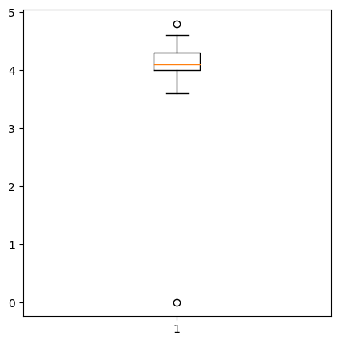

```python
plt.figure(figsize=(5,5))
plt.boxplot(data['Rating'])
plt.show()
```

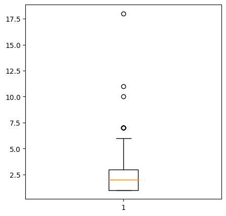

```python
plt.figure(figsize=(5,5))
plt.boxplot(data['Total_Cuisine'])

plt.show()
```

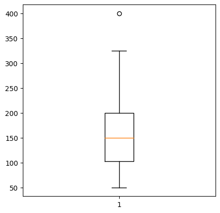

```python
plt.figure(figsize=(5,5))
plt.boxplot(data['Average_Cost'])
plt.show()
```

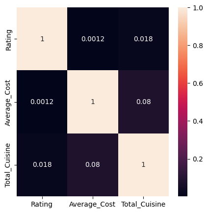

```python
plt.figure(figsize=(5,5))
sns.heatmap(data=data.corr(), annot=True)
plt.show()
```

- The graph indicates that there isn't exists any relationship between two attributes.

```python
category_group = data.groupby(by="Cost_Category")['Shop_Name'].count()
category_group
```

```
Cost_Category
high      10
low       51
medium    57
Name: Shop_Name, dtype: int64
```

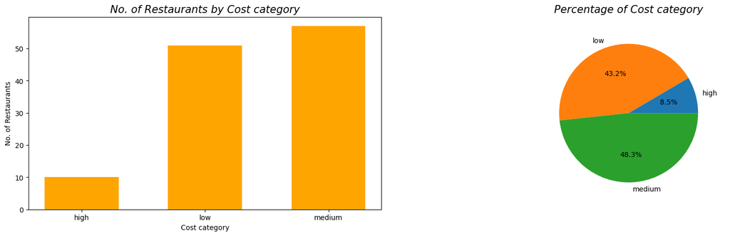

```python
plt.figure(figsize=(20,5))

plt.subplot(1,2,1)
plt.bar(category_group.index, category_group.values, color="orange", width=0.6)
plt.xlabel("Cost category", fontsize=10)
plt.ylabel("No. of Restaurants", fontsize=10)
plt.title("No. of Restaurants by Cost category", fontsize=15, fontstyle="italic")

plt.subplot(1,2,2)
plt.pie(category_group.values, radius=0.9, labels=category_group.index, autopct="%0.1f%%")
plt.title("Percentage of Cost category", fontsize=15, fontstyle="italic")

plt.show()
```

- The graphs shows that there are less restaurants where average cost per person is high.
- More than 90% restaurants have low or medium average cost per person

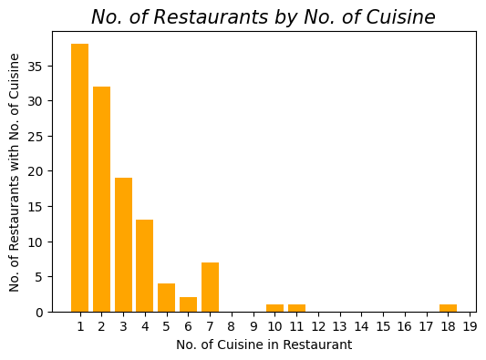

```python
plt.figure(figsize=(6,4))
plt.hist(x=data['Total_Cuisine'], bins=np.arange(1,20), align="left", rwidth=0.8, color='orange', histtype='bar')
plt.xticks(np.arange(1,20))
plt.xlabel('No. of Cuisine in Restaurant', fontsize=10)
plt.ylabel('No. of Restaurants with No. of Cuisine', fontsize=10)
plt.title("No. of Restaurants by No. of Cuisine", fontsize=15, fontstyle="italic")
plt.show()
```

- The graph indicates that more than 60 restaurants offers only one or two cuisine or dishes.
- There is only 3 restaurant which offers more than 7 cuisine or dishes.

```python
area_group = data.groupby(by=['Area'])['Shop_Name'].count()
area_group
```

```
Area
BTM            35
HSR            18
Jayanagar       1
Koramangala    64
Name: Shop_Name, dtype: int64
```

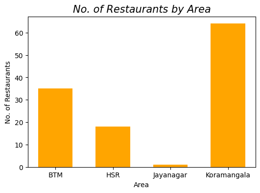

```python
plt.figure(figsize=(6,4))
plt.bar(area_group.index, area_group.values, color="orange", width=0.6)
plt.xlabel("Area", fontsize=10)
plt.ylabel("No. of Restaurants", fontsize=10)
plt.title("No. of Restaurants by Area", fontsize=15, fontstyle="italic")
```

- From the graph we can say that most restaurants are located in Koramangala.
- There is only one restaurant in Jayanagar so that we must have to collobrate with more restaurants in Jayanagar.

```python
area_average_cost_group = data.groupby(by=['Area'])['Average_Cost'].mean()
area_average_cost_group
```

```
Area
BTM            164.542857
HSR            194.444444
Jayanagar      150.000000
Koramangala    148.914062
Name: Average_Cost, dtype: float64
```

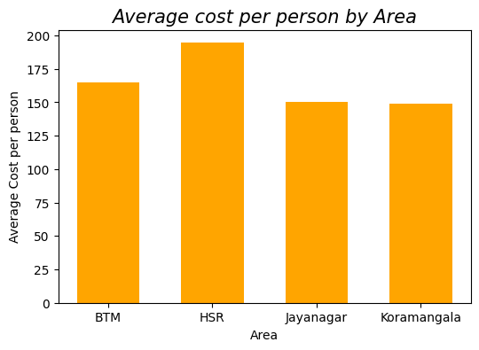

```python
plt.figure(figsize=(6,4))
plt.bar(area_average_cost_group.index, area_average_cost_group.values, color="orange", width=0.6)
plt.xlabel("Area", fontsize=10)
plt.ylabel("Average Cost per person", fontsize=10)
plt.title("Average cost per person by Area", fontsize=15, fontstyle="italic")
```

- Using the graph we can say that person must have minimum 150 Rupees to buy from swiggy in these areas.
- The highest average cost per person in HSR area so that we can say that Per Capita Income is more for that area

```python
rating_group = data.groupby(by=['Rating'])['Shop_Name'].count()
rating_group
```

```
Rating
0.0     1
3.6     2
3.7     6
3.8     4
3.9    13
4.0    21
4.1    30
4.2    10
4.3    23
4.4     4
4.5     1
4.6     2
4.8     1
Name: Shop_Name, dtype: int64
```

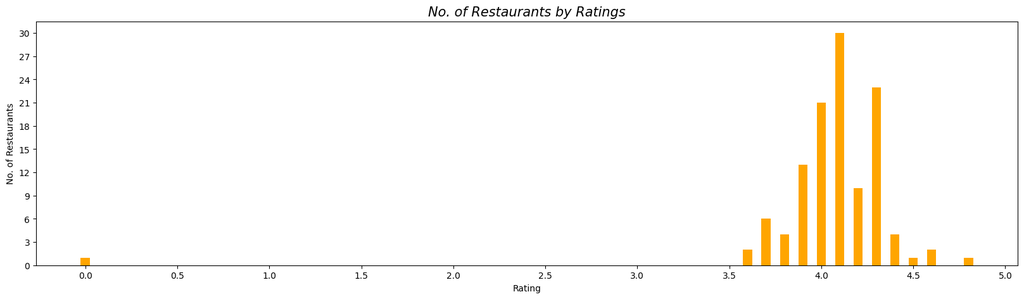

```python
plt.figure(figsize=(20,5))
plt.bar(rating_group.index, rating_group.values, color="orange", width=0.05)
plt.xlabel("Rating", fontsize=10)
plt.ylabel("No. of Restaurants", fontsize=10)
plt.title("No. of Restaurants by Ratings", fontsize=15, fontstyle="italic")
plt.xticks(np.arange(0,5.1,0.5))
plt.yticks(np.arange(0,31,3))
plt.show()
```

- The graph indicates that 30 restaurants have obtained rating of 4.1.
- Mandya Gowdru Donne Biryani shop has nothing obtained any rating yet.

```python
dishes = list(s.strip() for s in data['Cuisine'].sum().split(','))
counts = [dishes.count(i) for i in dishes]
cuisines = pd.DataFrame({"Cuisine":dishes, "Total_Count": counts})
cuisines.drop_duplicates(inplace=True)
cuisines.shape
```

```
(111, 2)
```

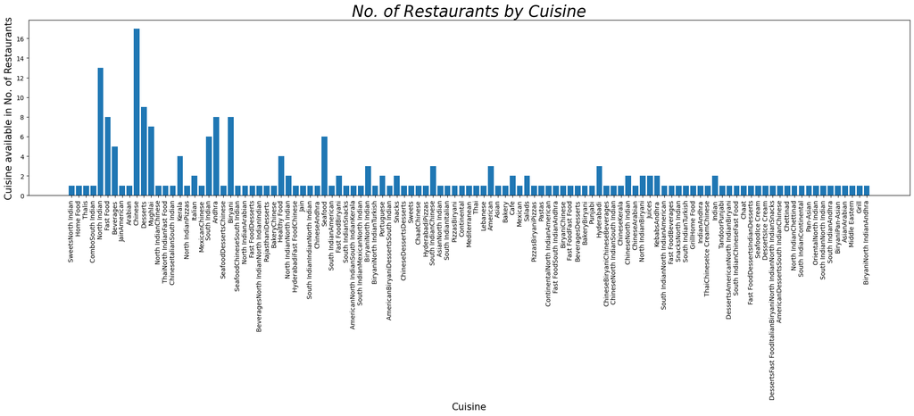

```python
plt.figure(figsize=(25,5))
plt.bar(cuisines['Cuisine'], cuisines['Total_Count'])
plt.xlabel("Cuisine", fontsize=15)
plt.ylabel("Cuisine available in No. of Restaurants", fontsize=15)
plt.title("No. of Restaurants by Cuisine", fontsize=25, fontstyle="italic")
plt.xticks(rotation=90)
plt.show()
```

- We can say that there are less cuisine that available in most restaurants.
- Chinese food available in the most restaurants with 17 restaurants.

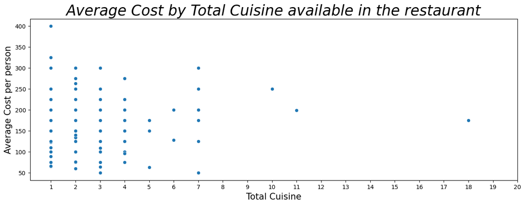

```python
plt.figure(figsize=(15,5))
sns.scatterplot(data=data, x='Total_Cuisine', y='Average_Cost')
plt.xlabel("Total Cuisine", fontsize=15)
plt.ylabel("Average Cost per person", fontsize=15)
plt.title("Average Cost by Total Cuisine available in the restaurant", fontsize=25, fontstyle="italic")
plt.xticks(np.arange(1,21,1))
plt.show()
```

- From the graph we can say that there is no relation between Average cost and Total Cuisine available in restaurant.
- The graph tells that if we increase cuisine of the Restaurants then average cost per person will be less or more.

### 9. Rating by Total Cuisine available in the restaurant

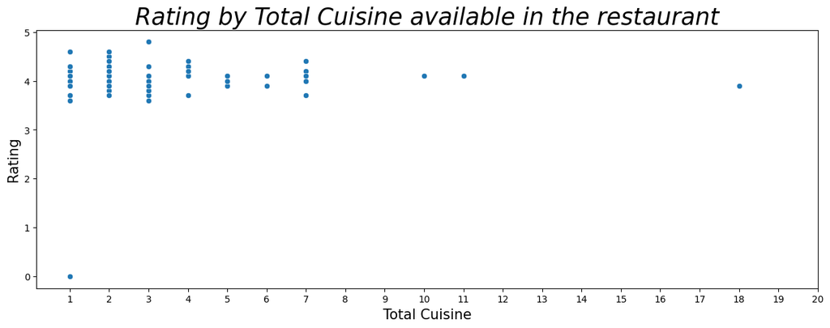

```python
plt.figure(figsize=(15,5))
sns.scatterplot(data=data, x='Total_Cuisine', y='Rating')
plt.xlabel("Total Cuisine", fontsize=15)
plt.ylabel("Rating", fontsize=15)
plt.title("Rating by Total Cuisine available in the restaurant", fontsize=25, fontstyle="italic")
plt.xticks(np.arange(1,21,1))
plt.show()
```

- From the graph we can say that there is no relation between Rating and Total Cuisine available in restaurant.
- The graph tells that if we increase cuisine of the Restaurants then Rating of that Restaurant will be good or bad.

### 10. Number of Restaurants by Street

```python
street_group = data.groupby(by=['Street'])['Shop_Name'].count()
street_group.drop_duplicates(inplace=True)
street_group
```

```
Street
16th Main Road     2
1st Block          5
1st Cross Road     1
4th Cross          3
5th Block         10
BTM               13
HSR                8
Koramangala       12
Name: Shop_Name, dtype: int64
```

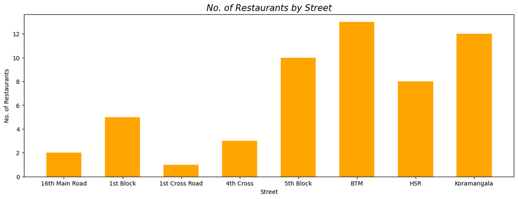

```python
plt.figure(figsize=(15,5))
plt.bar(street_group.index, street_group.values, color="orange", width=0.6)
plt.xlabel("Street", fontsize=10)
plt.ylabel("No. of Restaurants", fontsize=10)
plt.title("No. of Restaurants by Street", fontsize=15, fontstyle="italic")
plt.show()
```